# RCB_SRH

[figure not shown]

```python
#!pip install bqplot
#!pip install ipywidgets
#!pip install ipympl
#!jupyter labextension install @jupyter-widgets/jupyterlab-manager
#!jupyter nbextension install --user --py widgetsnbextension
#!jupyter nbextension enable --user --py widgetsnbextension
#!pip install plotly
#!pip install cufflinks


import operator
import pandas as pd
import numpy as np
import matplotlib.pyplot as plt
import seaborn as sns
%matplotlib inline
import warnings
warnings.filterwarnings("ignore")
import ipywidgets as widgets
import plotly.express as px
import plotly.graph_objects as go
import bqplot
from bqplot import Pie
from collections import Counter
from bqplot import DateScale, LinearScale, Lines, Axis, Figure
from bqplot import Tooltip
import cufflinks as cf
from matplotlib.patches import ConnectionPatch
from matplotlib.gridspec import GridSpec
import matplotlib.pyplot as plt

from IPython.core.display import display, HTML

def display_side_by_side(dfs:list, captions:list):
    """Display tables side by side to save vertical space
    Input:
        dfs: list of pandas.DataFrame
        captions: list of table captions
    """
    output = ""
    combined = dict(zip(captions, dfs))
    for caption, df in combined.items():
        output += df.style.set_table_attributes("style='display:inline'").set_caption(caption)._repr_html_()
        output += "\xa0\xa0\xa0"
    display(HTML(output))


from __future__ import print_function
from ipywidgets import interact, interactive, fixed, interact_manual
pd.set_option('display.max_columns', 50)
%matplotlib widget
```

```python
matches = pd.read_csv("matches.csv")
deliveries =  pd.read_csv("deliveries.csv")
IPL_data = pd.merge(deliveries, matches[['id','season', 'team1', 'team2', 'toss_winner', 'toss_decision','winner','result', 'dl_applied','win_by_runs','win_by_wickets', 'venue' ]],
                    left_on='match_id', right_on='id')
```

```python
RCB_batsmen = ['AJ Finch', 'V Kohli', 'AB de Villiers', 'Washington Sundar','Gurkeerat Singh', 'S Dube', 'CH Morris']
#D Paddikal: new player, S Dube/ Gurkeerat (optional)

RCB_bowlers = ['CH Morris', 'YS Chahal', 'N Saini', 'Washington Sundar','Mohammed Siraj','DW Steyn']
# I Udana new player: Bowler ER:9.72

SRH_batsmen = ['J Bairstow', 'DA Warner', 'MK Pandey', 'JO Holder', 'KS Williamson', 'Mohammad Nabi','V Shankar']
# Samad and Garg no data available
# Williamson injured hence will not likely to play
SRH_bowlers = ['Sandeep Sharma', 'K Ahmed', 'Rashid Khan', 'V Shankar', 'Basil Thampi', 'T Natarajan']
```

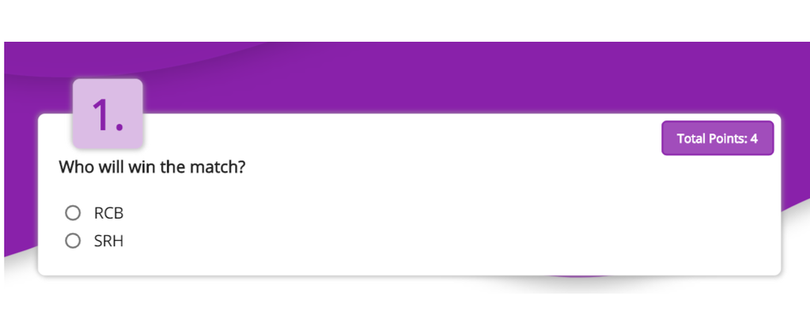

```python
bowling_avg = deliveries[(deliveries.bowler.isin(RCB_bowlers)) | (deliveries.bowler.isin(SRH_bowlers))]
bowling_avg.player_dismissed.fillna(0, inplace  = True)
bowling_avg['player_dismissed'].loc[bowling_avg['player_dismissed'] != 0] = 1

b_avg1 = bowling_avg.groupby(['bowler'])['player_dismissed'].sum().reset_index(name  = "wickets")
t_b =  bowling_avg.groupby(['bowler'])['batsman_runs'].count().reset_index(name  = "balls_bowled")
b_avg1["balls_bowled"] = t_b.balls_bowled
b_avg1["bowling_avg"] = b_avg1.wickets/b_avg1.balls_bowled


display_side_by_side([b_avg1[b_avg1.bowler.isin(RCB_bowlers)], b_avg1[b_avg1.bowler.isin(SRH_bowlers)]],
                     [" 1) bowling average of RCB bowlers", " 2) bowling average of SRH bowlers"])


## Batting averages of all the batsmen

batsmen_runs_all =deliveries[(deliveries.batsman.isin(RCB_batsmen)) | (deliveries.batsman.isin(SRH_batsmen))]
b1_all = batsmen_runs_all.groupby(['batsman'])['batsman_runs'].sum().reset_index(name = "total_runs")
b = [];b_avg = [];tm = [];runs  = []
for i in batsmen_runs_all.batsman.unique():
    x = batsmen_runs_all[batsmen_runs_all.batsman == i]
    x.player_dismissed.fillna(0, inplace = True)
    x['player_dismissed'].loc[x['player_dismissed'] != 0] = 1
    #print(x[['match_id','player_dismissed']])
    y = x.groupby(['match_id'])['player_dismissed'].sum().reset_index(name = "out_count")
    z = x.groupby(['match_id'])['batsman_runs'].sum().reset_index(name = "runs")
    #print(y)
    b.append(i)
    b_avg.append(y.out_count.sum())
    runs.append(z.runs.sum())
    tm.append(y.shape[0])

bat_avg = pd.DataFrame(list(zip(b, b_avg, tm, runs)),
               columns =['batsman','matches_out','matches', 'total_runs'])

bat_avg["batting_average"] = bat_avg.total_runs/bat_avg.matches_out

display_side_by_side([bat_avg[bat_avg.batsman.isin(RCB_batsmen)], bat_avg[bat_avg.batsman.isin(SRH_batsmen)]],
                     [" 1) batting average of RCB batsmen", " 2) batting average of SRH batsmen"])
```

1) bowling average of RCB bowlers

|  | bowler | wickets | balls_bowled | bowling_avg |
| --- | --- | --- | --- | --- |
| 1 | CH Morris | 78 | 1335 | 0.058427 |
| 2 | DW Steyn | 104 | 2207 | 0.047123 |
| 4 | Mohammed Siraj | 30 | 584 | 0.051370 |
| 5 | N Saini | 12 | 300 | 0.040000 |
| 10 | Washington Sundar | 17 | 358 | 0.047486 |
| 11 | YS Chahal | 102 | 1841 | 0.055405 |

2) bowling average of SRH bowlers

|  | bowler | wickets | balls_bowled | bowling_avg |
| --- | --- | --- | --- | --- |
| 0 | Basil Thampi | 20 | 413 | 0.048426 |
| 3 | K Ahmed | 20 | 241 | 0.082988 |
| 6 | Rashid Khan | 60 | 1106 | 0.054250 |
| 7 | Sandeep Sharma | 90 | 1546 | 0.058215 |
| 8 | T Natarajan | 2 | 82 | 0.024390 |
| 9 | V Shankar | 2 | 92 | 0.021739 |

1) batting average of RCB batsmen

|  | batsman | matches_out | matches | total_runs | batting_average |
| --- | --- | --- | --- | --- | --- |
| 1 | AJ Finch | 66 | 73 | 1744 | 26.424242 |
| 2 | CH Morris | 20 | 37 | 520 | 26.000000 |
| 4 | AB de Villiers | 104 | 142 | 4428 | 42.576923 |
| 6 | V Kohli | 152 | 169 | 5434 | 35.750000 |
| 9 | Washington Sundar | 6 | 12 | 79 | 13.166667 |
| 10 | Gurkeerat Singh | 26 | 27 | 446 | 17.153846 |
| 12 | S Dube | 4 | 4 | 40 | 10.000000 |

2) batting average of SRH batsmen

|  | batsman | matches_out | matches | total_runs | batting_average |
| --- | --- | --- | --- | --- | --- |
| 0 | DA Warner | 114 | 126 | 4741 | 41.587719 |
| 3 | MK Pandey | 96 | 119 | 2872 | 29.916667 |
| 5 | V Shankar | 17 | 27 | 574 | 33.764706 |
| 7 | Mohammad Nabi | 8 | 10 | 146 | 18.250000 |
| 8 | KS Williamson | 34 | 41 | 1319 | 38.794118 |
| 11 | JO Holder | 5 | 5 | 38 | 7.600000 |
| 13 | J Bairstow | 8 | 10 | 468 | 58.500000 |

```python
fig = px.bar(b_avg1, x="bowler", y='bowling_avg',
             hover_data=['bowler', 'bowling_avg', 'balls_bowled','wickets' ],color = 'bowler',
             title='Bowling averages of SRH and RCB bowlers')
#fig.show()

fig = px.bar(bat_avg, x="batsman", y='batting_average',
             hover_data=['batsman', 'batting_average', 'total_runs','matches', 'matches_out' ],color = 'batsman',
             title='Batting averages of SRH and RCB batsmen')
#fig.show()
```

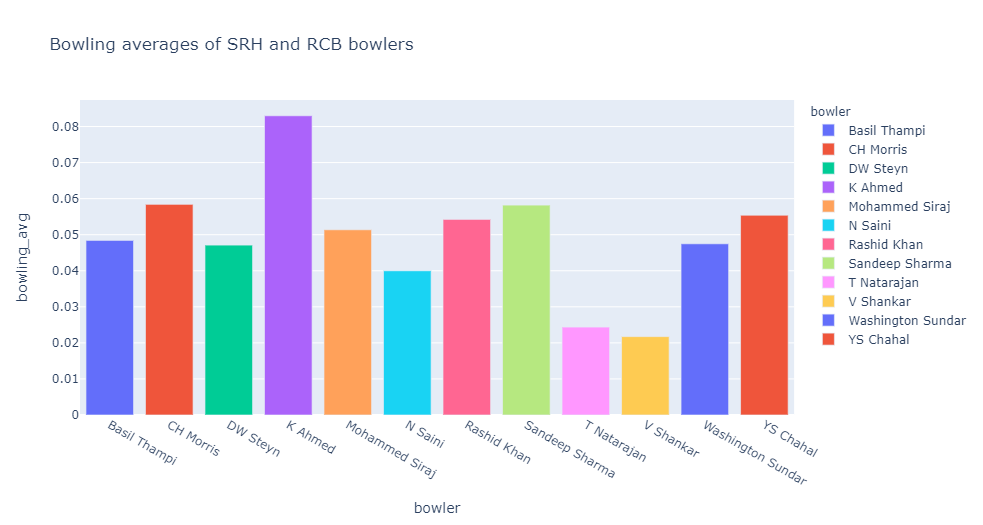

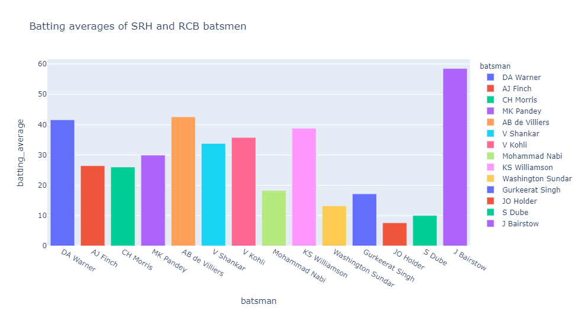

## Performance indexes of batsmen

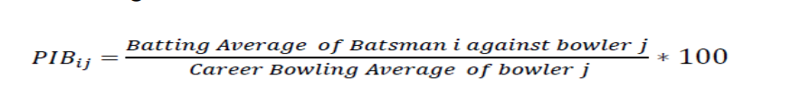

```python
# Performance indexes of RCB batsmen against SRH bowlers
batsman = [];bowler =[]; b_avg= []; runs= []; tm = []
def performance_indexes_batsmen(batsman_list, bowler_list):

    for i in batsman_list:
        pi1 = deliveries[(deliveries.batsman == i) & (deliveries.bowler.isin(bowler_list))]
        pi1.player_dismissed.fillna(0, inplace = True)
        pi1['player_dismissed'].loc[pi1['player_dismissed'] != 0] = 1
        for j in pi1.bowler.unique():
            x = pi1[pi1.bowler == j]
            batsman.append(i)
            bowler.append(j)
            y = x.groupby(['match_id'])['player_dismissed'].sum().reset_index(name = "out_count")
            z = x.groupby(['match_id'])['batsman_runs'].sum().reset_index(name = "runs")
            b_avg.append(y.out_count.sum())
            runs.append(z.runs.sum())
            tm.append(y.shape[0])

performance_indexes_batsmen(RCB_batsmen, SRH_bowlers)
RCB_bat_avg = pd.DataFrame(list(zip(batsman, bowler, b_avg, tm, runs)),
               columns =['batsman','bowler', 'matches_out','total_matches', 'total_runs'])
RCB_bat_avg["batting_average"] = RCB_bat_avg.total_runs/RCB_bat_avg.matches_out
RCB_bat_avg.replace([np.inf, -np.inf], np.nan, inplace=True)

bowl_avg = []
for i in RCB_bat_avg.bowler.values:
    bowl_avg.append(b_avg1[b_avg1.bowler == i].bowling_avg.values[0])

RCB_bat_avg["bowling_average_bowler"] = bowl_avg
RCB_bat_avg["PIBij"] = RCB_bat_avg.batting_average/RCB_bat_avg.bowling_average_bowler # not multiplying with 100 as bowling average is not in %

#############################################################################################################33
# SRH batsmen's performance indexes
batsman = [];bowler =[]; b_avg= []; runs= []; tm = []
performance_indexes_batsmen(SRH_batsmen, RCB_bowlers)

SRH_bat_avg = pd.DataFrame(list(zip(batsman, bowler, b_avg, tm, runs)),
               columns =['batsman','bowler', 'matches_out','total_matches', 'total_runs'])
SRH_bat_avg["batting_average"] = SRH_bat_avg.total_runs/SRH_bat_avg.matches_out
SRH_bat_avg.replace([np.inf, -np.inf], np.nan, inplace=True)

bowl_avg1 = []
for i in SRH_bat_avg.bowler.values:
    bowl_avg1.append(b_avg1[b_avg1.bowler == i].bowling_avg.values[0])

SRH_bat_avg["bowling_average_bowler"] = bowl_avg1
SRH_bat_avg["PIBij"] = SRH_bat_avg.batting_average/SRH_bat_avg.bowling_average_bowler # not multiplying with 100 as bowling average is not in %
display_side_by_side([RCB_bat_avg, SRH_bat_avg],
                     [" 1) Performance indexes of RCB batsmen against SRH Bowlers", " 2) Performance indexes of SRH batsmen against RCB Bowlers"])
```

1) Performance indexes of RCB batsmen against SRH Bowlers

|  | batsman | bowler | matches_out | total_matches | total_runs | batting_average | bowling_average_bowler | PIBij |
| --- | --- | --- | --- | --- | --- | --- | --- | --- |
| 0 | AJ Finch | Rashid Khan | 2 | 4 | 16 | 8.000000 | 0.054250 | 147.466667 |
| 1 | AJ Finch | Sandeep Sharma | 1 | 6 | 37 | 37.000000 | 0.058215 | 635.577778 |
| 2 | AJ Finch | T Natarajan | 0 | 1 | 7 | nan | 0.024390 | nan |
| 3 | V Kohli | Basil Thampi | 1 | 2 | 16 | 16.000000 | 0.048426 | 330.400000 |
| 4 | V Kohli | Sandeep Sharma | 5 | 9 | 61 | 12.200000 | 0.058215 | 209.568889 |
| 5 | V Kohli | T Natarajan | 0 | 1 | 0 | nan | 0.024390 | nan |
| 6 | V Kohli | Rashid Khan | 1 | 2 | 12 | 12.000000 | 0.054250 | 221.200000 |
| 7 | V Kohli | K Ahmed | 1 | 1 | 11 | 11.000000 | 0.082988 | 132.550000 |
| 8 | AB de Villiers | Sandeep Sharma | 2 | 8 | 87 | 43.500000 | 0.058215 | 747.233333 |
| 9 | AB de Villiers | T Natarajan | 0 | 1 | 1 | nan | 0.024390 | nan |
| 10 | AB de Villiers | Basil Thampi | 0 | 2 | 17 | nan | 0.048426 | nan |
| 11 | AB de Villiers | Rashid Khan | 2 | 2 | 8 | 4.000000 | 0.054250 | 73.733333 |
| 12 | AB de Villiers | K Ahmed | 0 | 1 | 1 | nan | 0.082988 | nan |
| 13 | Washington Sundar | K Ahmed | 1 | 1 | 1 | 1.000000 | 0.082988 | 12.050000 |
| 14 | Gurkeerat Singh | K Ahmed | 1 | 1 | 8 | 8.000000 | 0.082988 | 96.400000 |
| 15 | Gurkeerat Singh | Rashid Khan | 0 | 1 | 11 | nan | 0.054250 | nan |
| 16 | Gurkeerat Singh | Basil Thampi | 0 | 1 | 23 | nan | 0.048426 | nan |
| 17 | Gurkeerat Singh | V Shankar | 0 | 1 | 14 | nan | 0.021739 | nan |
| 18 | CH Morris | Sandeep Sharma | 1 | 2 | 14 | 14.000000 | 0.058215 | 240.488889 |
| 19 | CH Morris | Rashid Khan | 1 | 2 | 4 | 4.000000 | 0.054250 | 73.733333 |
| 20 | CH Morris | K Ahmed | 0 | 1 | 2 | nan | 0.082988 | nan |

2) Performance indexes of SRH batsmen against RCB Bowlers

|  | batsman | bowler | matches_out | total_matches | total_runs | batting_average | bowling_average_bowler | PIBij |
| --- | --- | --- | --- | --- | --- | --- | --- | --- |
| 0 | J Bairstow | Mohammed Siraj | 0 | 1 | 17 | nan | 0.051370 | nan |
| 1 | J Bairstow | YS Chahal | 1 | 1 | 9 | 9.000000 | 0.055405 | 162.441176 |
| 2 | J Bairstow | CH Morris | 0 | 2 | 22 | nan | 0.058427 | nan |
| 3 | DA Warner | CH Morris | 1 | 6 | 34 | 34.000000 | 0.058427 | 581.923077 |
| 4 | DA Warner | Washington Sundar | 0 | 2 | 22 | nan | 0.047486 | nan |
| 5 | DA Warner | DW Steyn | 2 | 5 | 42 | 21.000000 | 0.047123 | 445.644231 |
| 6 | DA Warner | YS Chahal | 1 | 7 | 116 | 116.000000 | 0.055405 | 2093.686275 |
| 7 | DA Warner | Mohammed Siraj | 1 | 1 | 17 | 17.000000 | 0.051370 | 330.933333 |
| 8 | MK Pandey | CH Morris | 0 | 4 | 21 | nan | 0.058427 | nan |
| 9 | MK Pandey | YS Chahal | 2 | 7 | 37 | 18.500000 | 0.055405 | 333.906863 |
| 10 | MK Pandey | Mohammed Siraj | 0 | 2 | 18 | nan | 0.051370 | nan |
| 11 | MK Pandey | Washington Sundar | 1 | 2 | 3 | 3.000000 | 0.047486 | 63.176471 |
| 12 | MK Pandey | DW Steyn | 0 | 6 | 21 | nan | 0.047123 | nan |
| 13 | MK Pandey | N Saini | 0 | 1 | 1 | nan | 0.040000 | nan |
| 14 | JO Holder | CH Morris | 1 | 1 | 0 | 0.000000 | 0.058427 | 0.000000 |
| 15 | KS Williamson | CH Morris | 2 | 3 | 13 | 6.500000 | 0.058427 | 111.250000 |
| 16 | KS Williamson | YS Chahal | 1 | 4 | 35 | 35.000000 | 0.055405 | 631.715686 |
| 17 | KS Williamson | Mohammed Siraj | 1 | 2 | 14 | 14.000000 | 0.051370 | 272.533333 |
| 18 | KS Williamson | Washington Sundar | 0 | 1 | 10 | nan | 0.047486 | nan |
| 19 | KS Williamson | N Saini | 0 | 1 | 8 | nan | 0.040000 | nan |
| 20 | Mohammad Nabi | CH Morris | 0 | 1 | 5 | nan | 0.058427 | nan |
| 21 | Mohammad Nabi | N Saini | 1 | 1 | 4 | 4.000000 | 0.040000 | 100.000000 |
| 22 | V Shankar | YS Chahal | 0 | 3 | 13 | nan | 0.055405 | nan |
| 23 | V Shankar | Mohammed Siraj | 0 | 1 | 9 | nan | 0.051370 | nan |
| 24 | V Shankar | CH Morris | 0 | 1 | 6 | nan | 0.058427 | nan |
| 25 | V Shankar | Washington Sundar | 1 | 1 | 13 | 13.000000 | 0.047486 | 273.764706 |

## Performance indexes for both the teams bowlers

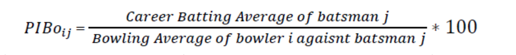

```python
bowls = []; bats = []; wi = []; bb = []
def performance_index_bowlers(bowlers_list, batsmen_list):
    for i in bowlers_list:
        p = deliveries[(deliveries.bowler == i) & (deliveries.batsman.isin(batsmen_list))]
        p.player_dismissed.fillna(0, inplace  = True)
        p['player_dismissed'].loc[p['player_dismissed'] != 0] = 1
        for j in p.batsman.unique():
            bowls.append(i)
            bats.append(j)
            xy = p[p.batsman == j]
            #print(p[p.batsman == j])
            wi.append(xy.player_dismissed.sum())
            bb.append(xy.batsman_runs.count())

performance_index_bowlers(RCB_bowlers, SRH_batsmen)
RCB_bowlers_p = pd.DataFrame(list(zip(bowls, bats, wi, bb)),
               columns =['bowler', 'batsman','wickets','balls_bowled'])
bat_avg_p = []
for i in RCB_bowlers_p.batsman.values:
    bat_avg_p.append(bat_avg[bat_avg.batsman == i].batting_average.values[0])

RCB_bowlers_p["bowling_average"] = RCB_bowlers_p.wickets/RCB_bowlers_p.balls_bowled
RCB_bowlers_p["batting_avg"] = bat_avg_p
RCB_bowlers_p["PIBoij"] = RCB_bowlers_p.batting_avg/RCB_bowlers_p.bowling_average
RCB_bowlers_p.replace([np.inf, -np.inf], np.nan, inplace=True)
###################################################################################################################
bowls = []; bats = []; wi = []; bb = []
performance_index_bowlers(SRH_bowlers, RCB_batsmen)

SRH_bowlers_p = pd.DataFrame(list(zip(bowls, bats, wi, bb)),
               columns =['bowler', 'batsman','wickets','balls_bowled'])
bat_avg_p = []
for i in SRH_bowlers_p.batsman.values:
    bat_avg_p.append(bat_avg[bat_avg.batsman == i].batting_average.values[0])

SRH_bowlers_p["bowling_average"] = SRH_bowlers_p.wickets/SRH_bowlers_p.balls_bowled
SRH_bowlers_p["batting_avg"] = bat_avg_p
SRH_bowlers_p["PIBoij"] = SRH_bowlers_p.batting_avg/SRH_bowlers_p.bowling_average
SRH_bowlers_p.replace([np.inf, -np.inf], np.nan, inplace=True)

display_side_by_side([RCB_bowlers_p, SRH_bowlers_p],
                     [" 1) Performance indexes of RCB bowlers against SRH batsmen", " 2) Performance indexes of SRH bowlers against RCB batsmen"])
```

1) Performance indexes of RCB bowlers against SRH batsmen

|  | bowler | batsman | wickets | balls_bowled | bowling_average | batting_avg | PIBoij |
| --- | --- | --- | --- | --- | --- | --- | --- |
| 0 | CH Morris | MK Pandey | 0 | 20 | 0.000000 | 29.916667 | nan |
| 1 | CH Morris | DA Warner | 1 | 28 | 0.035714 | 41.587719 | 1164.456140 |
| 2 | CH Morris | KS Williamson | 2 | 15 | 0.133333 | 38.794118 | 290.955882 |
| 3 | CH Morris | JO Holder | 1 | 1 | 1.000000 | 7.600000 | 7.600000 |
| 4 | CH Morris | J Bairstow | 0 | 11 | 0.000000 | 58.500000 | nan |
| 5 | CH Morris | V Shankar | 0 | 4 | 0.000000 | 33.764706 | nan |
| 6 | CH Morris | Mohammad Nabi | 0 | 5 | 0.000000 | 18.250000 | nan |
| 7 | YS Chahal | MK Pandey | 2 | 40 | 0.050000 | 29.916667 | 598.333333 |
| 8 | YS Chahal | DA Warner | 1 | 67 | 0.014925 | 41.587719 | 2786.377193 |
| 9 | YS Chahal | KS Williamson | 1 | 35 | 0.028571 | 38.794118 | 1357.794118 |
| 10 | YS Chahal | V Shankar | 0 | 9 | 0.000000 | 33.764706 | nan |
| 11 | YS Chahal | J Bairstow | 1 | 7 | 0.142857 | 58.500000 | 409.500000 |
| 12 | N Saini | MK Pandey | 0 | 1 | 0.000000 | 29.916667 | nan |
| 13 | N Saini | KS Williamson | 0 | 6 | 0.000000 | 38.794118 | nan |
| 14 | N Saini | Mohammad Nabi | 1 | 3 | 0.333333 | 18.250000 | 54.750000 |
| 15 | Washington Sundar | DA Warner | 0 | 24 | 0.000000 | 41.587719 | nan |
| 16 | Washington Sundar | MK Pandey | 1 | 5 | 0.200000 | 29.916667 | 149.583333 |
| 17 | Washington Sundar | KS Williamson | 0 | 9 | 0.000000 | 38.794118 | nan |
| 18 | Washington Sundar | V Shankar | 1 | 5 | 0.200000 | 33.764706 | 168.823529 |
| 19 | Mohammed Siraj | MK Pandey | 0 | 13 | 0.000000 | 29.916667 | nan |
| 20 | Mohammed Siraj | KS Williamson | 1 | 10 | 0.100000 | 38.794118 | 387.941176 |
| 21 | Mohammed Siraj | V Shankar | 0 | 6 | 0.000000 | 33.764706 | nan |
| 22 | Mohammed Siraj | DA Warner | 1 | 9 | 0.111111 | 41.587719 | 374.289474 |
| 23 | Mohammed Siraj | J Bairstow | 0 | 10 | 0.000000 | 58.500000 | nan |
| 24 | DW Steyn | DA Warner | 2 | 37 | 0.054054 | 41.587719 | 769.372807 |
| 25 | DW Steyn | MK Pandey | 0 | 24 | 0.000000 | 29.916667 | nan |

2) Performance indexes of SRH bowlers against RCB batsmen

|  | bowler | batsman | wickets | balls_bowled | bowling_average | batting_avg | PIBoij |
| --- | --- | --- | --- | --- | --- | --- | --- |
| 0 | Sandeep Sharma | AB de Villiers | 2 | 45 | 0.044444 | 42.576923 | 957.980769 |
| 1 | Sandeep Sharma | CH Morris | 1 | 9 | 0.111111 | 26.000000 | 234.000000 |
| 2 | Sandeep Sharma | AJ Finch | 1 | 34 | 0.029412 | 26.424242 | 898.424242 |
| 3 | Sandeep Sharma | V Kohli | 5 | 36 | 0.138889 | 35.750000 | 257.400000 |
| 4 | K Ahmed | CH Morris | 0 | 3 | 0.000000 | 26.000000 | nan |
| 5 | K Ahmed | V Kohli | 1 | 4 | 0.250000 | 35.750000 | 143.000000 |
| 6 | K Ahmed | AB de Villiers | 0 | 1 | 0.000000 | 42.576923 | nan |
| 7 | K Ahmed | Gurkeerat Singh | 1 | 8 | 0.125000 | 17.153846 | 137.230769 |
| 8 | K Ahmed | Washington Sundar | 1 | 2 | 0.500000 | 13.166667 | 26.333333 |
| 9 | Rashid Khan | AJ Finch | 2 | 9 | 0.222222 | 26.424242 | 118.909091 |
| 10 | Rashid Khan | V Kohli | 1 | 14 | 0.071429 | 35.750000 | 500.500000 |
| 11 | Rashid Khan | AB de Villiers | 2 | 10 | 0.200000 | 42.576923 | 212.884615 |
| 12 | Rashid Khan | CH Morris | 1 | 10 | 0.100000 | 26.000000 | 260.000000 |
| 13 | Rashid Khan | Gurkeerat Singh | 0 | 7 | 0.000000 | 17.153846 | nan |
| 14 | V Shankar | Gurkeerat Singh | 0 | 5 | 0.000000 | 17.153846 | nan |
| 15 | Basil Thampi | V Kohli | 1 | 17 | 0.058824 | 35.750000 | 607.750000 |
| 16 | Basil Thampi | AB de Villiers | 0 | 7 | 0.000000 | 42.576923 | nan |
| 17 | Basil Thampi | Gurkeerat Singh | 0 | 17 | 0.000000 | 17.153846 | nan |
| 18 | T Natarajan | AB de Villiers | 0 | 2 | 0.000000 | 42.576923 | nan |
| 19 | T Natarajan | AJ Finch | 0 | 2 | 0.000000 | 26.424242 | nan |
| 20 | T Natarajan | V Kohli | 0 | 2 | 0.000000 | 35.750000 | nan |

## Conclusion : By comparing above parameters, it seems SRH will win today

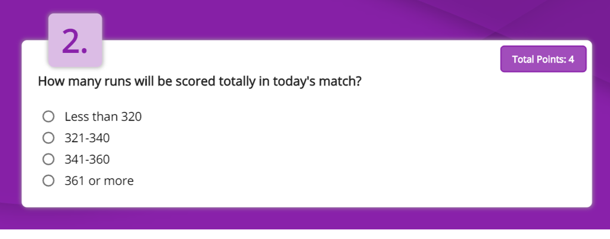

# 2.1 Matchwise average score of every batsmam

```python
def average_scores(players_data):

    for i in players_data.batsman.unique():
        balls.append(players_data[players_data.batsman ==i].balls_faced.mean())
        r_scored.append(players_data[players_data.batsman ==i].runs_scored.mean())
        batsman_name.append(i)

    RCB_SRH_runs_data =  pd.DataFrame(list(zip(batsman_name, balls, r_scored)),
               columns =['batsman','balls_faced','runs_scored'])
    return RCB_SRH_runs_data



RCB_SRH_b = batsmen_runs_all.groupby(['match_id', 'batsman'])['batsman_runs'].sum().reset_index(name = "runs_scored")
RCB_SRH_runs = batsmen_runs_all.groupby(['match_id', 'batsman'])['batsman_runs'].count().reset_index(name = "balls_faced")
RCB_SRH_runs["runs_scored"] = RCB_SRH_b.runs_scored
r_scored=[];batsman_name=[];balls = []
RCB_SRH_runs_data_ = average_scores(RCB_SRH_runs)

display_side_by_side([RCB_SRH_runs_data_[RCB_SRH_runs_data_.batsman.isin(RCB_batsmen)],
                      RCB_SRH_runs_data_[RCB_SRH_runs_data_.batsman.isin(SRH_batsmen)]],
                     [" 1) Runs scored by RCB batsmen", " 2) Runs scired by SRH batsmen"])
```

1) Runs scored by RCB batsmen

|  | batsman | balls_faced | runs_scored |
| --- | --- | --- | --- |
| 1 | AJ Finch | 18.794521 | 23.890411 |
| 2 | CH Morris | 9.162162 | 14.054054 |
| 4 | AB de Villiers | 20.964789 | 31.183099 |
| 6 | V Kohli | 24.917160 | 32.153846 |
| 9 | Washington Sundar | 4.666667 | 6.583333 |
| 10 | Gurkeerat Singh | 13.074074 | 16.518519 |
| 12 | S Dube | 8.250000 | 10.000000 |

2) Runs scired by SRH batsmen

|  | batsman | balls_faced | runs_scored |
| --- | --- | --- | --- |
| 0 | DA Warner | 26.968254 | 37.626984 |
| 3 | MK Pandey | 20.378151 | 24.134454 |
| 5 | V Shankar | 15.888889 | 21.259259 |
| 7 | Mohammad Nabi | 9.500000 | 14.600000 |
| 8 | KS Williamson | 23.926829 | 32.170732 |
| 11 | JO Holder | 6.400000 | 7.600000 |
| 13 | J Bairstow | 29.300000 | 46.800000 |

```python
print("total score of RCB and SRH :", RCB_SRH_runs_data.runs_scored.sum() +10 +7) # adding averages of Samad and Garg as data not available in this data set
```

```
total score of RCB and SRH : 335.57469048527855
```

# 2.2 head to head scores of SRH and RCB batsmen agaisnt each others bowlers

```python
SRH_RCB_faceoff = deliveries[((deliveries.batsman.isin(RCB_batsmen)) & (deliveries.bowler.isin(SRH_bowlers))) |
                            ((deliveries.batsman.isin(SRH_batsmen)) & (deliveries.bowler.isin(RCB_bowlers)))]
SRH_RCB_faceoff_b = SRH_RCB_faceoff.groupby(['match_id', 'batsman'])['batsman_runs'].sum().reset_index(name = "runs_scored")
SRH_RCB_faceoff_runs = SRH_RCB_faceoff.groupby(['match_id', 'batsman'])['batsman_runs'].count().reset_index(name = "balls_faced")
SRH_RCB_faceoff_runs["runs_scored"] = SRH_RCB_faceoff_b.runs_scored
r_scored=[];batsman_name=[];balls = []
RCB_SRH_runs_data_faceoff = average_scores(SRH_RCB_faceoff_runs)

# Calculate probable runs scored head to head
p_runs =[];batsmen =[]
for i in RCB_SRH_runs_data_faceoff.batsman.unique():
    batsmen.append(i)
    faceoff_score =  RCB_SRH_runs_data_faceoff[RCB_SRH_runs_data_faceoff.batsman ==i]
    overall_score = RCB_SRH_runs_data_[RCB_SRH_runs_data_.batsman == i]
    predicted_runs = (faceoff_score.runs_scored.values[0]/faceoff_score.balls_faced.values[0])*overall_score.balls_faced.values[0]
    p_runs.append(predicted_runs)

RCB_SRH_runs_data_head_to_head =  pd.DataFrame(list(zip(batsmen, p_runs)),
               columns =['batsman','predicted_runs'])

display_side_by_side([RCB_SRH_runs_data_head_to_head[RCB_SRH_runs_data_head_to_head.batsman.isin(RCB_batsmen)],
                      RCB_SRH_runs_data_head_to_head[RCB_SRH_runs_data_head_to_head.batsman.isin(SRH_batsmen)]],
                     [" 1) Runs scored by RCB batsmen against SRH bowlers", " 2) Runs scired by SRH batsmen against RCB bowlers"])
```

1) Runs scored by RCB batsmen against SRH bowlers

|  | batsman | predicted_runs |
| --- | --- | --- |
| 0 | AJ Finch | 25.059361 |
| 1 | AB de Villiers | 36.769014 |
| 2 | CH Morris | 8.329238 |
| 4 | V Kohli | 34.133096 |
| 11 | Gurkeerat Singh | 19.787788 |
| 12 | Washington Sundar | 2.333333 |

2) Runs scired by SRH batsmen against RCB bowlers

|  | batsman | predicted_runs |
| --- | --- | --- |
| 3 | MK Pandey | 19.982459 |
| 5 | DA Warner | 37.755556 |
| 6 | KS Williamson | 25.521951 |
| 7 | JO Holder | 0.000000 |
| 8 | V Shankar | 27.143519 |
| 9 | J Bairstow | 50.228571 |
| 10 | Mohammad Nabi | 10.687500 |

```python
print("Head to head runs of RCB and SRH are : ", RCB_SRH_runs_data_head_to_head.predicted_runs.sum() +10 + 11) # Samad and garg's runs added
```

```
Head to head runs of RCB and SRH are :  318.7313855568195
```

# Comclusion: From part 2.1 and 2.2 the score will be in between 318-335,according to options in question answer is 321-340

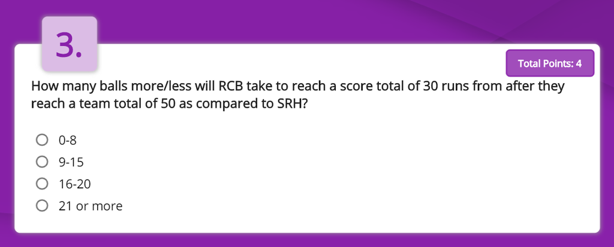

# Using the results of analysis deon in question 2

```python
# RCB
batsman_RCB = []; balls_ = []; runs_ = []
for i in RCB_batsmen:
    batsman_RCB.append(i)
    balls_.append(RCB_SRH_runs_data_[RCB_SRH_runs_data_.batsman ==i].balls_faced.values[0])
    runs_.append(RCB_SRH_runs_data_[RCB_SRH_runs_data_.batsman ==i].runs_scored.values[0])
RCB_cumulative =  pd.DataFrame(list(zip(batsman_RCB, balls_, runs_)),
               columns =['batsman','balls_faced', "runs"])


# SRH
batsman_SRH = []; balls_ = []; runs_ = []
for i in SRH_batsmen:
    batsman_SRH.append(i)
    balls_.append(RCB_SRH_runs_data_[RCB_SRH_runs_data_.batsman ==i].balls_faced.values[0])
    runs_.append(RCB_SRH_runs_data_[RCB_SRH_runs_data_.batsman ==i].runs_scored.values[0])
SRH_cumulative =  pd.DataFrame(list(zip(batsman_SRH, balls_, runs_)),
               columns =['batsman','balls_faced', "runs"])

display_side_by_side([RCB_cumulative.cumsum(), SRH_cumulative.cumsum()],
                     [" 1) Runs scored by RCB batsmen cumulative", " 2) Runs scired by SRH batsmen cumulative"])
```

1) Runs scored by RCB batsmen cumulative

|  | batsman | balls_faced | runs |
| --- | --- | --- | --- |
| 0 | AJ Finch | 18.794521 | 23.890411 |
| 1 | AJ FinchV Kohli | 43.711680 | 56.044257 |
| 2 | AJ FinchV KohliAB de Villiers | 64.676469 | 87.227356 |
| 3 | AJ FinchV KohliAB de VilliersWashington Sundar | 69.343136 | 93.810689 |
| 4 | AJ FinchV KohliAB de VilliersWashington SundarGurkeerat Singh | 82.417210 | 110.329208 |
| 5 | AJ FinchV KohliAB de VilliersWashington SundarGurkeerat SinghS Dube | 90.667210 | 120.329208 |
| 6 | AJ FinchV KohliAB de VilliersWashington SundarGurkeerat SinghS DubeCH Morris | 99.829372 | 134.383262 |

2) Runs scired by SRH batsmen cumulative

|  | batsman | balls_faced | runs |
| --- | --- | --- | --- |
| 0 | J Bairstow | 29.300000 | 46.800000 |
| 1 | J BairstowDA Warner | 56.268254 | 84.426984 |
| 2 | J BairstowDA WarnerMK Pandey | 76.646405 | 108.561438 |
| 3 | J BairstowDA WarnerMK PandeyJO Holder | 83.046405 | 116.161438 |
| 4 | J BairstowDA WarnerMK PandeyJO HolderKS Williamson | 106.973234 | 148.332170 |
| 5 | J BairstowDA WarnerMK PandeyJO HolderKS WilliamsonMohammad Nabi | 116.473234 | 162.932170 |
| 6 | J BairstowDA WarnerMK PandeyJO HolderKS WilliamsonMohammad NabiV Shankar | 132.362123 | 184.191429 |

```python
print("RCB will take 10 balls to reach ", RCB_cumulative.runs.max()/RCB_cumulative.balls_faced.max() *10)
print("RCB will take 20 balls to reach ", RCB_cumulative.runs.max()/RCB_cumulative.balls_faced.max() *20)
print("RCB will take 30 balls to reach ", RCB_cumulative.runs.max()/RCB_cumulative.balls_faced.max() *30)
print("RCB will take 35 balls to reach ", RCB_cumulative.runs.max()/RCB_cumulative.balls_faced.max() *35)
print("RCB will take 39 balls to reach ", RCB_cumulative.runs.max()/RCB_cumulative.balls_faced.max() *39)
print("RCB will take 40 balls to reach ", RCB_cumulative.runs.max()/RCB_cumulative.balls_faced.max() *40)
print("RCB will take 50 balls to reach ", RCB_cumulative.runs.max()/RCB_cumulative.balls_faced.max() *50)
print("RCB will take 62 balls to reach ", RCB_cumulative.runs.max()/RCB_cumulative.balls_faced.max() *62)
```

```
RCB will take 10 balls to reach  12.904298266445025
RCB will take 20 balls to reach  25.80859653289005
RCB will take 30 balls to reach  38.712894799335075
RCB will take 35 balls to reach  45.16504393255759
RCB will take 39 balls to reach  50.326763239135595
RCB will take 40 balls to reach  51.6171930657801
RCB will take 50 balls to reach  64.52149133222512
RCB will take 62 balls to reach  80.00664925195915
```

## As shown in above results, RCB will take 39 balls to reach 50 and it will take 62 balls to reach to 80 , i.e. it will take 23 more balls to score 30 runs after scoring its 50

```python
print("SRH will take 10 balls to reach ", SRH_cumulative.runs.max()/SRH_cumulative.balls_faced.max() *10)
print("SRH will take 20 balls to reach ", SRH_cumulative.runs.max()/SRH_cumulative.balls_faced.max() *20)
print("SRH will take 30 balls to reach ", SRH_cumulative.runs.max()/SRH_cumulative.balls_faced.max() *30)
print("SRH will take 32 balls to reach ", SRH_cumulative.runs.max()/SRH_cumulative.balls_faced.max() *32)
print("SRH will take 39 balls to reach ", SRH_cumulative.runs.max()/SRH_cumulative.balls_faced.max() *39)
print("SRH will take 40 balls to reach ", SRH_cumulative.runs.max()/SRH_cumulative.balls_faced.max() *40)
print("SRH will take 50 balls to reach ", SRH_cumulative.runs.max()/SRH_cumulative.balls_faced.max() *50)
```

```
SRH will take 10 balls to reach  15.972696245733786
SRH will take 20 balls to reach  31.945392491467572
SRH will take 30 balls to reach  47.91808873720136
SRH will take 32 balls to reach  51.112627986348116
SRH will take 39 balls to reach  62.293515358361766
SRH will take 40 balls to reach  63.890784982935145
SRH will take 50 balls to reach  79.86348122866893
```

## As shown in above results, SRH will take 32 balls to reach 50 and it will take 50 balls to reach 80, i.e. it will take 18 more balls to score 30 runs after scoring its 50

## hence,RCB will take 5 more balls than SRH to score 30 after scoring its first 50

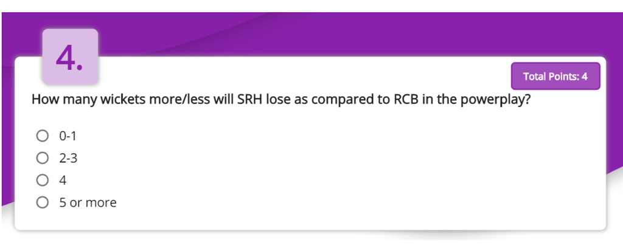

## 4.1 RCB and SRH bowler's wickets in powerplay

```python
RCB_bowlers_pp = deliveries[(deliveries.bowler.isin(RCB_bowlers)) & (deliveries.over <=6)]
RCB_bowlers_pp.player_dismissed.fillna(0, inplace = True)
RCB_bowlers1 = RCB_bowlers_pp[RCB_bowlers_pp.player_dismissed !=0].groupby(['match_id', 'bowler'])['player_dismissed'].count().reset_index(name = "wickets")
wickets_count=[];RCB_b=[]
for i in RCB_bowlers1.bowler.unique():
    RCB_b.append(i)
    wickets_count.append(round(RCB_bowlers1[RCB_bowlers1.bowler == i].wickets.mean(),1))
RCB_wickets_powerplay =  pd.DataFrame(list(zip(RCB_b, wickets_count)),
               columns =['bowler','wickets_powerplay'])

###############################################################################################################

SRH_bowlers_pp = deliveries[(deliveries.bowler.isin(SRH_bowlers)) & (deliveries.over <=6)]
SRH_bowlers_pp.player_dismissed.fillna(0, inplace = True)
SRH_bowlers1 = SRH_bowlers_pp[SRH_bowlers_pp.player_dismissed !=0].groupby(['match_id', 'bowler'])['player_dismissed'].count().reset_index(name = "wickets")

wickets_count=[];SRH_b=[]
for i in SRH_bowlers1.bowler.unique():
    SRH_b.append(i)
    wickets_count.append(round(SRH_bowlers1[SRH_bowlers1.bowler == i].wickets.mean(),1))
SRH_wickets_powerplay =  pd.DataFrame(list(zip(SRH_b, wickets_count)),
               columns =['bowler','wickets_powerplay'])


display_side_by_side([RCB_wickets_powerplay, SRH_wickets_powerplay],
                     ["1) RCB wickets in powerplay", "2) SRH wickets in powerplay"])
```

1) RCB wickets in powerplay

|  | bowler | wickets_powerplay |
| --- | --- | --- |
| 0 | CH Morris | 1.100000 |
| 1 | YS Chahal | 1.200000 |
| 2 | Mohammed Siraj | 1.000000 |
| 3 | Washington Sundar | 1.700000 |
| 4 | DW Steyn | 1.200000 |
| 5 | N Saini | 1.000000 |

2) SRH wickets in powerplay

|  | bowler | wickets_powerplay |
| --- | --- | --- |
| 0 | Rashid Khan | 1.000000 |
| 1 | Sandeep Sharma | 1.400000 |
| 2 | Basil Thampi | 1.000000 |
| 3 | K Ahmed | 1.400000 |

```python
RCB_batsmen_pp = ['AJ Finch', 'V Kohli', 'AB de Villiers']
SRH_batsmen_pp = ['J Bairstow', 'DA Warner','MK Pandey']
```

```python
powerplay_batsmen_matches = deliveries[((deliveries.batsman.isin(RCB_batsmen_pp)) | (deliveries.batsman.isin(SRH_batsmen_pp))) &
                              (deliveries.over <=6)]
powerplay_batsmen = deliveries[((deliveries.batsman.isin(RCB_batsmen_pp)) | (deliveries.batsman.isin(SRH_batsmen_pp))) ]

powerplay_batsmen_wickets = powerplay_batsmen.groupby(['batsman'])['player_dismissed'].count().reset_index(name = "out_in_powerplay")

matches_total=[]
for i in powerplay_batsmen_wickets.batsman.unique():
    matches_total.append(len(powerplay_batsmen[powerplay_batsmen.batsman == i].match_id.unique()))

powerplay_batsmen_wickets["total_matches"] = matches_total
powerplay_batsmen_wickets["out % in powerplay"] = (powerplay_batsmen_wickets.out_in_powerplay/powerplay_batsmen_wickets.total_matches) *100
RCB = powerplay_batsmen_wickets[powerplay_batsmen_wickets.batsman.isin(RCB_batsmen)]
SRH = powerplay_batsmen_wickets[powerplay_batsmen_wickets.batsman.isin(SRH_batsmen)]

display_side_by_side([RCB, SRH],
                     [" 1) Wickets of RCB batsmen in powerplay", " 2) Wickets of SRH batsmen in powerplay"])
```

1) Wickets of RCB batsmen in powerplay

|  | batsman | out_in_powerplay | total_matches | out % in powerplay |
| --- | --- | --- | --- | --- |
| 0 | AB de Villiers | 104 | 142 | 73.239437 |
| 1 | AJ Finch | 66 | 73 | 90.410959 |
| 5 | V Kohli | 152 | 169 | 89.940828 |

2) Wickets of SRH batsmen in powerplay

|  | batsman | out_in_powerplay | total_matches | out % in powerplay |
| --- | --- | --- | --- | --- |
| 2 | DA Warner | 114 | 126 | 90.476190 |
| 3 | J Bairstow | 8 | 10 | 80.000000 |
| 4 | MK Pandey | 96 | 119 | 80.672269 |

```python
fig = px.bar(powerplay_batsmen_wickets, x="batsman", y='out % in powerplay',
             hover_data=['batsman', 'out % in powerplay', 'out_in_powerplay','total_matches' ],color = 'batsman',
             title='% of wickets loss by SRH and RCB batsmen in powerplay')
#fig.show()
```

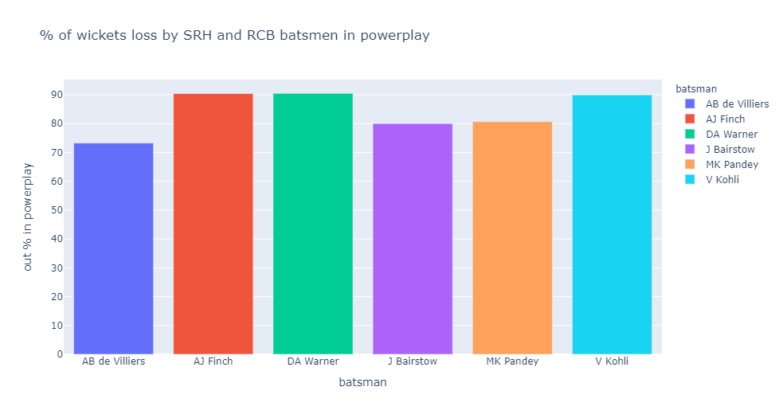

## 4.3 Percentage of wickets taken by RCB and SRH bowlers in power play

```python
powerplay_bowlers_matches = deliveries[((deliveries.bowler.isin(RCB_bowlers)) | (deliveries.bowler.isin(SRH_bowlers))) &
                              (deliveries.over <=6)]
powerplay_bowlers_ = deliveries[((deliveries.bowler.isin(RCB_bowlers)) | (deliveries.bowler.isin(SRH_bowlers))) ]

powerplay_bowlers_wickets = powerplay_bowlers_matches.groupby(['bowler'])['player_dismissed'].count().reset_index(name = "wickets_powerplay")

matches_total1=[]
for i in powerplay_bowlers_wickets.bowler.unique():
    matches_total1.append(len(powerplay_bowlers_[powerplay_bowlers_.bowler == i].match_id.unique()))

powerplay_bowlers_wickets["total_matches"] = matches_total1
powerplay_bowlers_wickets["wicket %powerplay"] = (powerplay_bowlers_wickets.wickets_powerplay/powerplay_bowlers_wickets.total_matches)*100
RCB1 = powerplay_bowlers_wickets[powerplay_bowlers_wickets.bowler.isin(RCB_bowlers)]
SRH1 = powerplay_bowlers_wickets[powerplay_bowlers_wickets.bowler.isin(SRH_bowlers)]

display_side_by_side([RCB1, SRH1],
                     [" 1) Wickets by RCB bowlers in powerplay", " 2) Wickets by SRH bowlers in powerplay"])
```

1) Wickets by RCB bowlers in powerplay

|  | bowler | wickets_powerplay | total_matches | wicket %powerplay |
| --- | --- | --- | --- | --- |
| 1 | CH Morris | 21 | 61 | 34.426230 |
| 2 | DW Steyn | 36 | 92 | 39.130435 |
| 4 | Mohammed Siraj | 5 | 26 | 19.230769 |
| 5 | N Saini | 3 | 13 | 23.076923 |
| 9 | Washington Sundar | 5 | 20 | 25.000000 |
| 10 | YS Chahal | 15 | 83 | 18.072289 |

2) Wickets by SRH bowlers in powerplay

|  | bowler | wickets_powerplay | total_matches | wicket %powerplay |
| --- | --- | --- | --- | --- |
| 0 | Basil Thampi | 2 | 19 | 10.526316 |
| 3 | K Ahmed | 7 | 10 | 70.000000 |
| 6 | Rashid Khan | 7 | 46 | 15.217391 |
| 7 | Sandeep Sharma | 44 | 68 | 64.705882 |
| 8 | T Natarajan | 0 | 6 | 0.000000 |

```python
fig = px.bar(powerplay_bowlers_wickets, x="bowler", y='wicket %powerplay',
             hover_data=['bowler', 'wicket %powerplay', 'wickets_powerplay','total_matches' ],color = 'bowler',
             title='% of wickets taken by SRH and RCB bowlers in powerplay')
#fig.show()
```

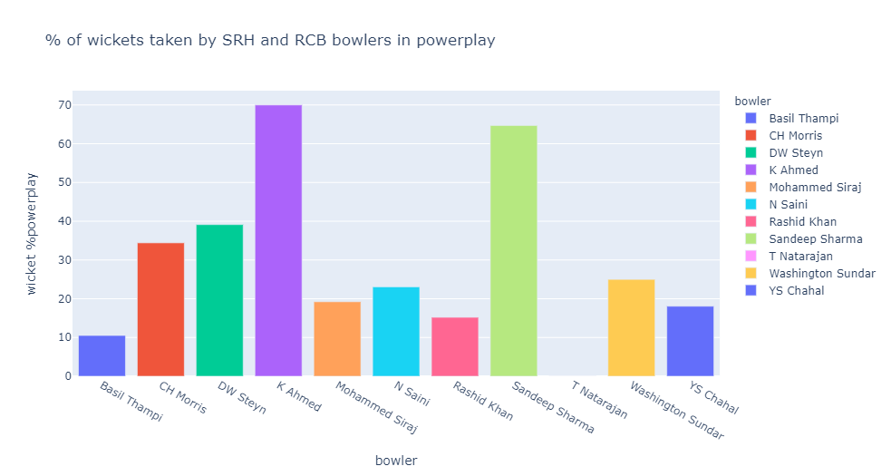

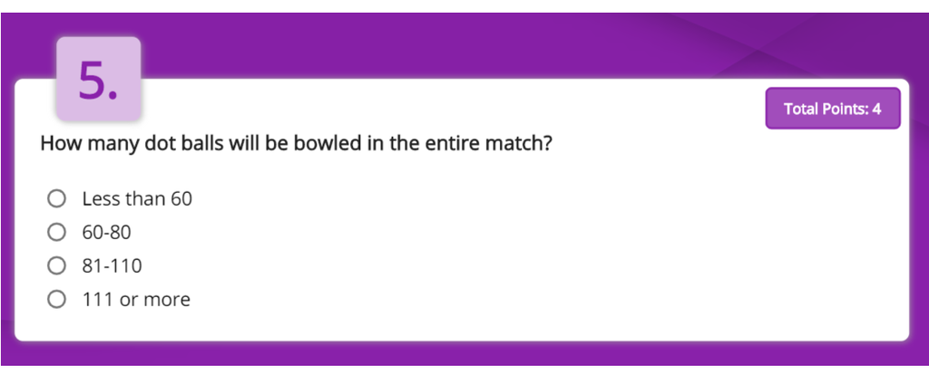

```python
dot = deliveries[(deliveries.bowler.isin(RCB_bowlers)) | (deliveries.bowler.isin(SRH_bowlers))]
dot_balls = dot[(dot.batsman_runs == 0) & (dot.extra_runs == 0)].groupby(['match_id', 'bowler'])['batsman_runs'].count().reset_index(name  = "dot_balls")
bowler_dot=[];dotb=[]
for i in dot_balls.bowler.unique():
    bowler_dot.append(i)
    dotb.append(dot_balls[dot_balls.bowler == i].dot_balls.mean())

total_dotballs = pd.DataFrame((list(zip(bowler_dot, dotb))), columns =["bowler", "dot_balls"])
fig = px.bar(total_dotballs, x="bowler", y='dot_balls',
             hover_data=['bowler', 'dot_balls'],color = 'bowler',
             title='Dot balls bowled by RCB and SRH bowlers')
#fig.show()
```

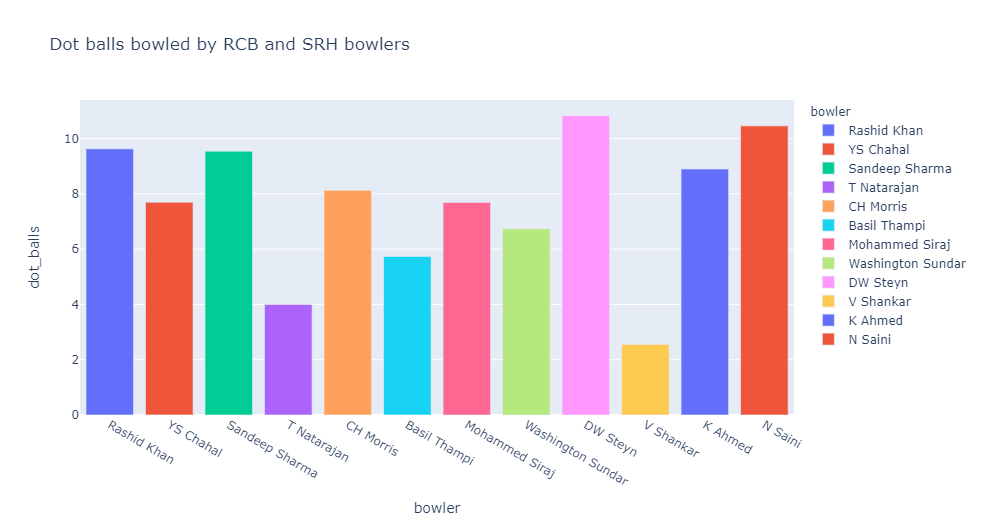

```python
print("total dot balls bowled will be : ",total_dotballs.dot_balls.sum())
```

```
total dot balls bowled will be :  91.91366802782379
```

## Conclusion : Dot balls will be 81-110